# Day 6: Advanced EDA & Patterns - In-Class Activity

Econ 122

2025-09-21

# 📊 Day 6: Advanced EDA & Patterns - In-Class Activity

Welcome to your in-class activity for Day 6! Today, you’ll apply the advanced Exploratory Data Analysis (EDA) techniques we discussed, focusing on identifying patterns, relationships, anomalies, and data transformations, using an **actual World Happiness Report dataset (2023)**. This dataset tracks **happiness scores**, **GDP per capita**, **social support**, and **healthy life expectancy** across various countries and regions. It offers **interesting variations** and **distinct patterns** throughout the world, making it ideal for deeper exploration of global well-being and economic trends.

**Estimated Time:** 40 minutes

**Instructions:**

1. Work through each section.
2. Execute the R code chunks as you go.
3. Answer any questions or complete any coding tasks.
4. Feel free to discuss with your peers!

## Part 1: Global Happiness & Economy Relationships (15 minutes)

In this section, you’ll explore relationships between happiness scores and economic indicators using scatter plots, faceting, and correlation matrices.

### Task 1.0: GDP Per Capita vs. Happiness Score with Trend Line

Create a scatter plot showing `GDP_per_capita_raw` (GDP per capita) on the x-axis and `happiness` (Happiness Score) on the y-axis from the `whr_data` dataset. Add a linear regression line (`geom_smooth(method = "lm", se = FALSE)`) to visualize the overall trend.

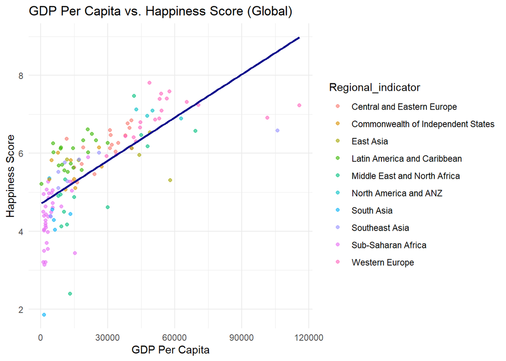

```r
ggplot(whr_data, aes(x = GDP_per_capita_raw, y = happiness)) +
  geom_point(alpha = 0.6, aes(color = Regional_indicator)) + # Color points by region
  geom_smooth(method = "lm", se = FALSE, color = "darkblue") +
  labs(title = "GDP Per Capita vs. Happiness Score (Global)",
       x = "GDP Per Capita", y = "Happiness Score") +
  theme_minimal()
```

### Task 1.1: Log GDP Per Capita vs. Happiness Score with Trend Line

Do the same thing but use `Logged_GDP_per_capita` (Log GDP per capita) on the x-axis instead. What are the main differences between the `raw` and `log` versions?

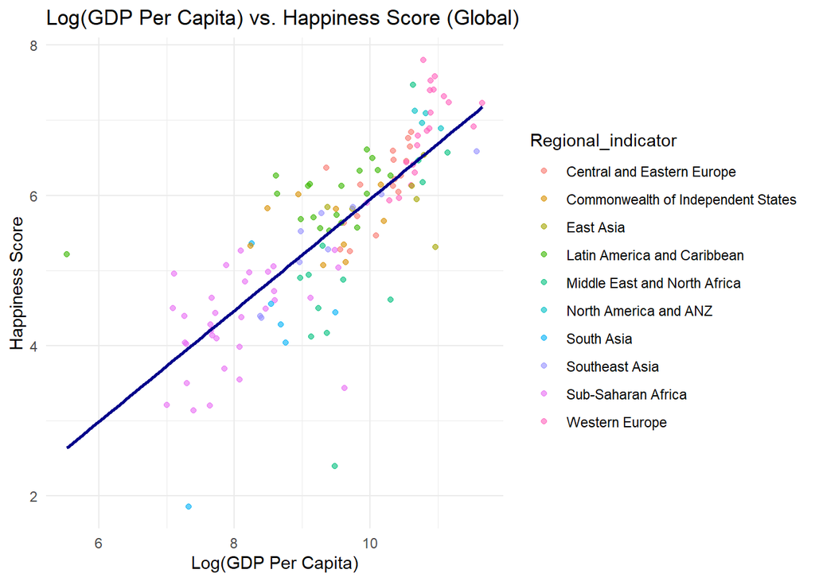

```r
# Your code here for Log GDP vs Happiness Score with linear trend
ggplot(whr_data, aes(x = Logged_GDP_per_capita, y = happiness)) +
  geom_point(alpha = 0.6, aes(color = Regional_indicator)) + # Color points by region
  geom_smooth(method = "lm", se = FALSE, color = "darkblue") +
  labs(title = "Log(GDP Per Capita) vs. Happiness Score (Global)",
       x = "Log(GDP Per Capita)", y = "Happiness Score") +
  theme_minimal()
```

The log version tends to have a better linear fit because there are lot of observations on either extreme (0 or very large numbers)

### Task 1.2: Faceting by Regional Indicator

Take the previous plot (Log GDP Per Capita vs. Happiness Score) and use `facet_wrap(~ Regional_indicator)` to create separate plots for each region. Observe how the relationship between Log GDP and happiness changes across these different regions. Do you notice **more distinct patterns** or different slopes for certain regions, indicating varying factors influencing happiness?

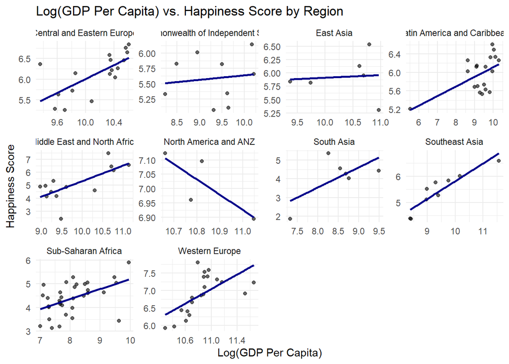

```r
# Your code here for faceted Log GDP vs Happiness Score plot by Regional Indicator
ggplot(whr_data, aes(x = Logged_GDP_per_capita, y = happiness)) +
  geom_point(alpha = 0.6) +
  facet_wrap(~ Regional_indicator, scales = "free") + # Faceting by region, free scales to better see within-region patterns
  geom_smooth(method = "lm", se = FALSE, color = "darkblue") +
  labs(title = "Log(GDP Per Capita) vs. Happiness Score by Region",
       x = "Log(GDP Per Capita)", y = "Happiness Score") +
  theme_minimal()
```

### Task 1.3: Visualizing a Correlation Matrix

Generate a heatmap of the correlation matrix for the numerical measurements in `whr_data` (`happiness`, `Logged_GDP_per_capita`, `Social_support`, `Healthy_life_expectancy`, `Freedom_to_make_life_choices`, `Generosity`, `Perceptions_of_corruption`). This will help you quickly identify strong positive and negative linear relationships between these global well-being indicators.

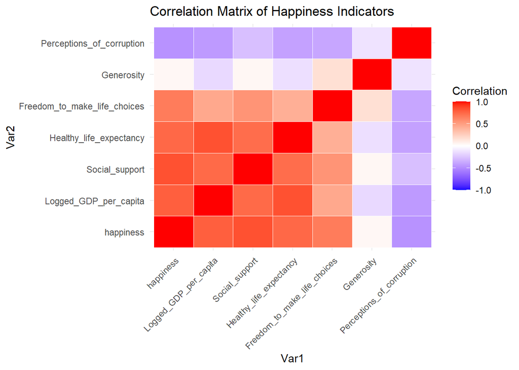

```r
# Select numerical columns for correlation calculation
numerical_whr <- whr_data %>%
  select(happiness, Logged_GDP_per_capita, Social_support, Healthy_life_expectancy,
         Freedom_to_make_life_choices, Generosity, Perceptions_of_corruption)
cor_matrix_whr <- cor(numerical_whr)

# Convert correlation matrix to long format for ggplot2
melted_cor_whr <- melt(cor_matrix_whr)

# Your code here for correlation heatmap
ggplot(melted_cor_whr, aes(x = Var1, y = Var2, fill = value)) +
  geom_tile(color = "white") +
  scale_fill_gradient2(low = "blue", high = "red", mid = "white",
                       midpoint = 0, limit = c(-1,1),
                       name = "Correlation") +
  theme_minimal() +
  theme(axis.text.x = element_text(angle = 45, vjust = 1, hjust = 1)) +
  labs(title = "Correlation Matrix of Happiness Indicators")
```

## Part 2: Anomaly Detection in Global Data (15 minutes)

In this section, you’ll use visual and statistical methods to identify potential anomalies (outliers) in the `happiness` (happiness score) variables of the `whr_data` dataset. These might represent countries with unusually high/low happiness for their region/economic context.

### Task 2.1: Outliers in Happiness Score

Explore outliers in the `happiness` score using both visual and statistical methods.

#### Task 2.1.1: Box Plot for Happiness Score Outliers

Create a box plot of `happiness` to visually identify outliers. Given the nature of real-world data, you might observe some interesting outliers.

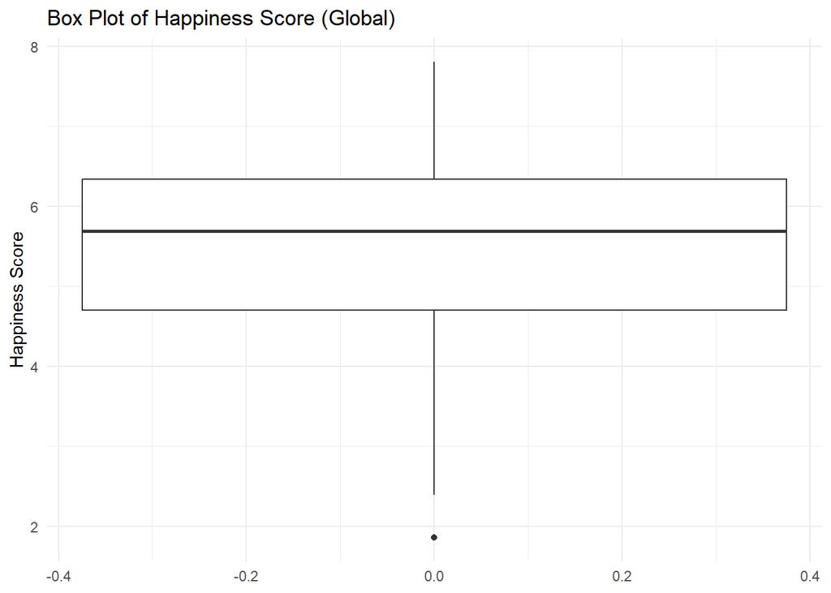

```r
# Your code here for box plot of happiness
ggplot(whr_data, aes(y = happiness)) +
  geom_boxplot() +
  labs(title = "Box Plot of Happiness Score (Global)", y = "Happiness Score") +
  theme_minimal()
```

#### Task 2.1.2: IQR Method for Happiness Score

Calculate the IQR for `happiness`. Identify and print the `Country_name`, `Regional_indicator`, and `happiness` for any entries that fall outside the $Q1 - 1.5 \\times IQR$ and $Q3 + 1.5 \\times IQR$ bounds. These could be countries with unusually low or high happiness scores.

```r
# Calculate Q1, Q3, and IQR for 'happiness'
Q1_hap <- quantile(whr_data$happiness, 0.25)
Q3_hap <- quantile(whr_data$happiness, 0.75)
IQR_val_hap <- Q3_hap - Q1_hap

# Define outlier bounds
lower_bound_hap <- Q1_hap - 1.5 * IQR_val_hap
upper_bound_hap <- Q3_hap + 1.5 * IQR_val_hap

# Your code here to identify and print IQR outliers
outliers_iqr_happiness <- whr_data[whr_data$happiness < lower_bound_hap |
                                          whr_data$happiness > upper_bound_hap,
                                        c("Country_name", "Regional_indicator", "happiness")]
print(head(outliers_iqr_happiness, 10)) # Print top 10 outliers
```

```
## # A tibble: 1 × 3
##   Country_name Regional_indicator happiness
##   <chr>        <chr>                  <dbl>
## 1 Afghanistan  South Asia              1.86
```

#### Task 2.1.3: Z-score Method for Happiness Score (Identifying More Outliers)

Calculate the Z-score for each country’s `happiness`. Identify and print the `Country_name`, `Regional_indicator`, and `happiness` for any entries with an absolute Z-score greater than **1.5**. Using this lower threshold will typically identify **even more outliers**, allowing for a broader examination of unusual data points.

```r
# Calculate Z-scores for 'happiness'
whr_data$happiness_zscore <- scale(whr_data$happiness)

# Your code here to identify and print Z-score outliers using a lower threshold
outliers_zscore_happiness_more <- whr_data[abs(whr_data$happiness_zscore) > 1.5,
                                           c("Country_name", "Regional_indicator", "happiness", "happiness_zscore")]
# For large datasets, printing head might be more practical
print(head(outliers_zscore_happiness_more, 15)) # Print top 15 outliers to show more
```

```
## # A tibble: 15 × 4
##    Country_name     Regional_indicator           happiness happiness_zscore[,1]
##    <chr>            <chr>                            <dbl>                <dbl>
##  1 Afghanistan      South Asia                        1.86                -3.22
##  2 Botswana         Sub-Saharan Africa                3.44                -1.85
##  3 Comoros          Sub-Saharan Africa                3.54                -1.75
##  4 Congo (Kinshasa) Sub-Saharan Africa                3.21                -2.05
##  5 Denmark          Western Europe                    7.59                 1.79
##  6 Finland          Western Europe                    7.80                 1.98
##  7 Iceland          Western Europe                    7.53                 1.74
##  8 Israel           Middle East and North Africa      7.47                 1.69
##  9 Lebanon          Middle East and North Africa      2.39                -2.76
## 10 Malawi           Sub-Saharan Africa                3.50                -1.79
## 11 Netherlands      Western Europe                    7.40                 1.63
## 12 Norway           Western Europe                    7.32                 1.55
## 13 Sierra Leone     Sub-Saharan Africa                3.14                -2.11
## 14 Sweden           Western Europe                    7.40                 1.62
## 15 Tanzania         Sub-Saharan Africa                3.69                -1.62
```

## Part 3: Data Transformation & Categorical Visualization (10 minutes)

This section focuses on transforming data to improve visualization and exploring relationships between categorical variables.

### Task 3.1: Effect of Log Transformation on GDP Per Capita

Explore the distribution of raw GDP per capita and its log-transformed version. Create two histograms side-by-side: one for `GDP_per_capita_raw` and one for `Logged_GDP_per_capita`. Observe how the log transformation changes the distribution’s shape, making it more symmetric and suitable for linear modeling.

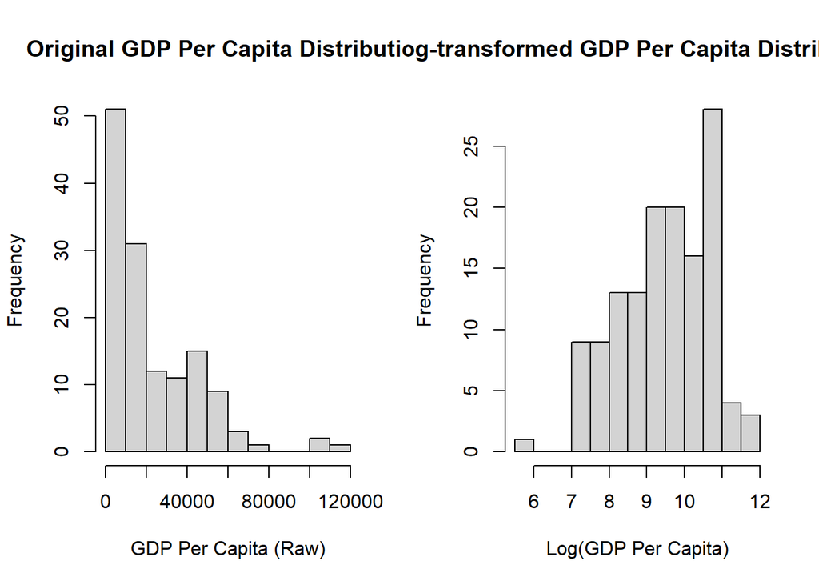

```r
# Your code here for histograms of original and log-transformed GDP per capita
par(mfrow = c(1, 2)) # Arrange plots side by side
hist(whr_data$GDP_per_capita_raw, main = "Original GDP Per Capita Distribution", xlab = "GDP Per Capita (Raw)")
hist(whr_data$Logged_GDP_per_capita, main = "Log-transformed GDP Per Capita Distribution", xlab = "Log(GDP Per Capita)")
```

### Task 3.2: Stacked Bar Chart of Happiness Distribution by Region

Create a stacked bar chart showing the **count of countries** within each `Regional_indicator` that fall into different `happiness_bin` categories (“Low Happiness”, “Medium Happiness”, “High Happiness”). This will allow you to visualize the distribution of happiness levels across regions. What do you notice?

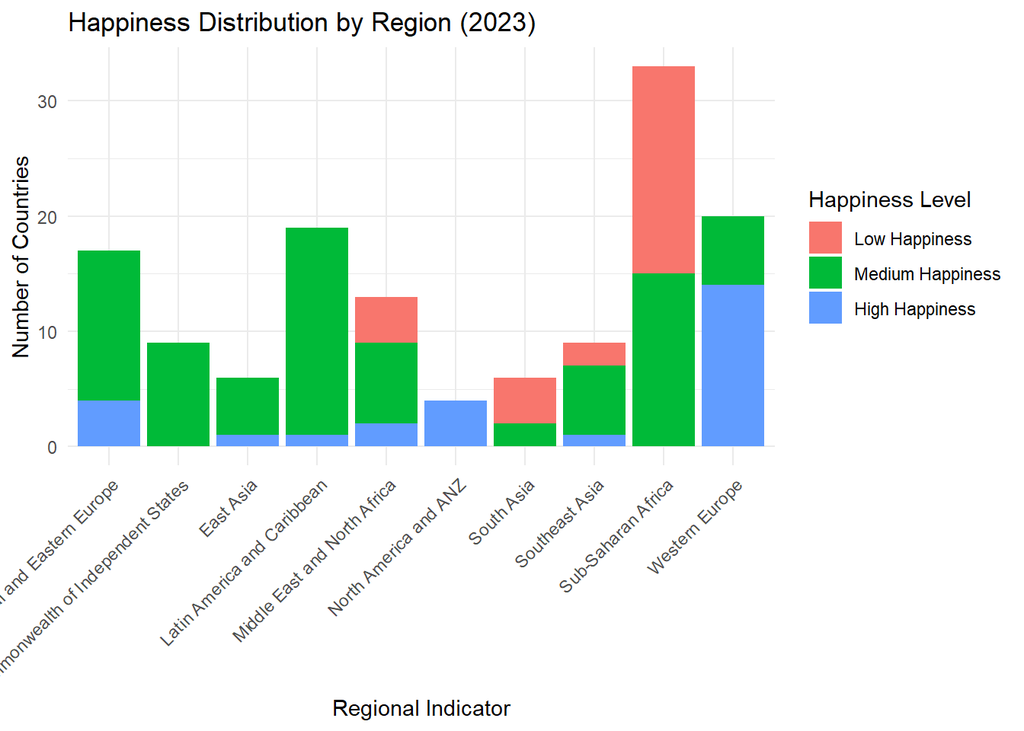

```r
# Your code here for stacked bar chart of happiness distribution by region
ggplot(whr_data, aes(x = Regional_indicator, fill = happiness_bin)) +
  geom_bar(position = "stack") + # 'stack' creates a stacked bar chart
  labs(title = "Happiness Distribution by Region (2023)",
       x = "Regional Indicator", y = "Number of Countries", fill = "Happiness Level") +
  theme_minimal() +
  theme(axis.text.x = element_text(angle = 45, hjust = 1)) # Rotate x-axis labels for readability
```

## ✨ Activity Wrap-up

Great job working through these advanced EDA concepts! You’ve practiced:

- Using **faceting** to compare relationships across groups (specifically by `Regional_indicator`, revealing distinct patterns related to happiness and economic indicators).
- Visualizing trends with **`geom_smooth()`**.
- Identifying linear relationships with **correlation matrices** and **heatmaps**.
- Detecting anomalies using **box plots**, **Z-score**, and **IQR methods**, including identifying **extreme outliers** in happiness scores.
- Transforming skewed data (like GDP per capita) with **log transformations** to improve visualization.
- Visualizing relationships between categorical variables using **stacked bar charts** to show distributions.

### Discussion Points:

- Compare the Z-score and IQR methods for detecting outliers in `happiness`. Which method identified more outliers and why might that be the case for these specific variables?
- How did faceting by `Regional_indicator` provide different insights into the relationship between Log GDP per capita and Happiness Score, potentially highlighting socio-economic disparities?
- Think of another real-world dataset where identifying obvious data errors or extreme outliers (like a country with an unusually low life expectancy given its high GDP) would be crucial before further analysis related to global well-being.